# Project 1: Deadlock Meta Analysis

Tiana Nguyen

2026-10-14

[figure not shown]

[output not shown]

## Background

Deadlock is a third-person shooter and multiplayer online battle arena (MOBA) that is currently in active development and in an invite-only closed beta. The game is the work of Valve, the company behind Steam, the Half-Life series, Counter-Strike, Portal, and more. In a match, two teams of six players each pick a different hero and fight to destroy the other side’s base as players collect “souls,” the in-game currency used to buy items and grow stronger. Every hero has their own unique abilities.

I will be talking about the game’s meta, which just means which heroes are the strongest in the current state of the game. The meta changes a lot because the game gets constant patches, but we will be looking at one particular specific patch.

[figure not shown]

The data came as two csv files:

- Hero stats by hero, rank, and day: wins, losses, matches, and the totals of kills, deaths, assists, net worth (souls), last hits, denies, player damage dealt and taken, boss damage, shots hit and missed, and permanent buffs.
- Hero bans by hero, rank, and day: the number of times each hero was banned in matches.

The variables that matter most for my analysis are the hero, the rank, the date, wins and matches (which give win rate and pick rate), bans, and the per-match stats like deaths, souls, and shot accuracy.

With this data I want to answer three questions:

1. What does the current hero meta look like, and do the most picked or most banned heroes win the most?
2. Which heroes get better as players climb in rank, and which ones fade?
3. What changes about how people play as they get better, and which stats go along with winning?

I hope what I learn through this project helps me get better as a player.

## Data Wrangling and Cleaning

When I request data from the API, the data comes in two data sets. Most of the wrangling was getting the two tables into one consistent structure and turing raw coutns of matches into rates that I can compare.

- Firstly, I selected only relevant variables in the stats data set. The stats file has more than 30 variables that are tracked. For the meta analysis, I kept identifiers, ranks, and win/loss/match counts.
- Then, I joined the stats and bans tables. The bans data was in a separate csv when I requested the data, so I used a full join on hero, day (`bucket`), and rank (`badge`). A full join keeps rows that exist in only one table. About 99 ban rows (0.03% of all bans) had no matching stats row, so they carry no hero name and are dropped when I summarize by hero. That is too small to matter, but I checked it rather than assuming.
- I handled missing values. For example, after the join, hero-days with no bans have `NA`, which really means zero bans, so I replaced those with 0. Likewise, missing wins, losses, and matches became 0.
- Changing variable types to make them more legible. The API gives time as a Unix timestamp (`bucket`), which is unreadable. I converted it to a real date so I can plot and filter by day.
- Then, I created new variables, since raw counts cannot be compared fairly across heroes and ranks because some ranks have far more games than others. I created win rate (wins divided by matches), pick rate (a hero’s matches divided by all matches, so the numbers sum to 1 across heroes), ban share (a hero’s bans divided by all bans), and bans per 100 games. Because each game has 12 players, I divided matches by 12 to estimate the number of games.
- Filtering unreliable observations. About 35% of the individual hero-rank-day rows come from fewer than 50 matches, which makes their win rates very noisy. So I never judge a hero from one day. I always aggregate across days first, and for the rank analysis I only keep hero-rank cells with at least 200 matches.

```r
stats <- read_csv("hero_stats_by_rank_subrank_and_date.csv")
bans  <- read_csv("hero_bans_by_rank_subrank_and_date.csv")
combined <- stats %>%
  select(hero_id, hero_name, bucket, badge, rank_tier, rank_name, subrank,
         wins, losses, matches, matches_per_bucket) %>%
  full_join(select(bans, hero_id, bucket, badge, bans),
            by = c("hero_id", "bucket", "badge")) %>%
  mutate(bans = replace_na(bans, 0),
         across(c(wins, losses, matches), ~ replace_na(.x, 0)),
         date = as_date(as_datetime(bucket))) %>%
  group_by(badge, date) %>%
  mutate(matches_per_bucket = max(matches_per_bucket, na.rm = TRUE),
         total_bans = sum(bans),
         ban_share = if_else(total_bans > 0, bans / total_bans, NA_real_),
         pick_rate = matches / matches_per_bucket,
         win_rate = if_else(matches > 0, wins / matches, NA_real_),
         bans_per_100_games = 100 * bans / (matches_per_bucket / 12)) %>%
  ungroup()
```

#### Hero Icons

I wanted the plots to show each hero’s icon instead of a plain labeled dot, so I pulled the icons from the API, shrank them, and saved them in a separate data frame.

```r
heroes_raw <- fromJSON("https://api.deadlock-api.com/v1/assets/heroes", flatten = TRUE)
img_cols <- names(heroes_raw)[str_detect(names(heroes_raw), "^images\\.")]

preferred <- c("images,icon_hero_card", "images.icon_image_small", "images.selection_image", "images.minimap_image")

img_col <- c(intersect(preferred, img_cols), img_cols)[1]

dir.create("hero_icons", showWarnings = FALSE)

icons <- heroes_raw %>%
  transmute(hero_id = id, icon_url = .data[[img_col]]) %>%
  filter(!is.na(icon_url)) %>%
  mutate(icon_file = file.path("hero_icons", paste0(hero_id, ".png")))

walk2(icons$icon_url, icons$icon_file, function(u, f) {
  if (!file.exists(f)) {
    tmp <- tempfile()
    try({
      download.file(u, tmp, mode = "wb", quiet = TRUE)
      image_read(tmp) %>% image_scale("96x96") %>% image_write(f, format = "png")
    }, silent = TRUE)
  }
})
icons <- icons %>% filter(file.exists(icon_file))
```

#### Scatter Plot Function

To make the scatter plots easier to build, I wrote a function that takes a data frame and two variables and draws each hero’s icon at its position. I also built the `hero` table here, which has one row per hero with its overall win rate, pick rate, and ban share.

```r
icon_scatter <- function(df, xvar, yvar, xlab, ylab, title, sx = 0.05, sy = 0.075) {
  df <- df %>% filter(!is.na(icon_url))
  x <- df[[xvar]]; y <- df[[yvar]]
  xr <- diff(range(x)); yr <- diff(range(y))

  imgs <- pmap(list(x, y, df$icon_url), function(xx, yy, u) {
    list(source = u, xref = "x", yref = "y", x = xx, y = yy,
         sizex = xr * sx, sizey = yr * sy,
         xanchor = "center", yanchor = "middle", layer = "above")
  })

  hover <- paste0(df$hero_name, "<br>", xlab, ": ", signif(x, 3),
                  "<br>", ylab, ": ", signif(y, 3))

  plot_ly(x = x, y = y, type = "scatter", mode = "markers",
          marker = list(size = 20, opacity = 0.01),
          text = hover, hoverinfo = "text") %>%
    layout(title = title,
           xaxis = list(title = xlab, range = c(min(x) - xr * 0.1, max(x) + xr * 0.1)),
           yaxis = list(title = ylab, range = c(min(y) - yr * 0.1, max(y) + yr * 0.1)),
           images = imgs)
}

hero <- combined %>%
  group_by(hero_id, hero_name) %>%
  summarise(matches = sum(matches),
            wins = sum(wins),
            bans = sum(bans), .groups = "drop") %>%
  mutate(win_rate = wins / matches,
         pick_rate = matches / sum(matches),
         ban_share = bans / sum(bans)) %>%
  left_join(icons, by = "hero_id") %>%
  filter(!is.na(hero_name))
```

#### Further Data Wrangling

Next I built a second table with one row per hero per rank. It turns every raw total into a per-match average (for example, total deaths divided by matches), so ranks with more games don’t look bigger than they are.

```r
min_matches <- 200

rank_levels <- stats %>%
  filter(!is.na(rank_tier)) %>%
  distinct(rank_tier, rank_name) %>%
  arrange(rank_tier) %>%
  pull(rank_name)

hero_rank <- stats %>%
  filter(!is.na(rank_tier), !is.na(hero_name)) %>%
  group_by(hero_id, hero_name, rank_tier, rank_name) %>%
  summarise(across(c(wins, matches, total_kills, total_deaths, total_assists,
                     total_net_worth, total_last_hits, total_denies,
                     total_player_damage, total_player_damage_taken,
                     total_boss_damage, total_shots_hit, total_shots_missed,
                     total_permanent_buffs, permanent_buff_matches),
                   ~ sum(.x, na.rm = TRUE)),
            .groups = "drop") %>%
  filter(matches >= min_matches) %>%
  mutate(rank_name = factor(rank_name, levels = rank_levels),
         win_rate  = wins / matches,
         kills     = total_kills / matches,
         deaths    = total_deaths / matches,
         assists   = total_assists / matches,
         net_worth = total_net_worth / matches,
         last_hits = total_last_hits / matches,
         denies    = total_denies / matches,
         damage_dealt  = total_player_damage / matches,
         damage_taken  = total_player_damage_taken / matches,
         boss_damage   = total_boss_damage / matches,
         accuracy      = total_shots_hit / (total_shots_hit + total_shots_missed),
         permanent_buffs = if_else(permanent_buff_matches > 0,
                                   total_permanent_buffs / permanent_buff_matches,
                                   NA_real_))
```

## Data Analysis

### Overall Look

I’ll start with the big picture. Which heroes do players pick, which do they ban, and which ones actually win?

#### Pick rate

Before a match starts, every player picks one hero, so pick rate shows how often the community chooses each hero. A high pick rate can mean a hero is strong, fun, easy to play, or simply new and exciting, and a low win rate with a high pick rate suggests players like the hero more than the results justify.

```r
icon_scatter(hero,
             "pick_rate",
             "win_rate",
             "Pick rate (share of all picks)",
             "Win rate",
             "Pick rate vs win rate") %>%
  layout(shapes = list(list(type = "line",
                            x0=0,x1=1, y0=0.5, y1=0.5,
                            line = list(dash = "dash", color = "grey"))))
```

[interactive chart not shown]

Each icon is a hero, and the dashed line is a 50% win rate. I will point out the obvious first. The clear outliers are Rat King and Haze, where their win rate and pick rate are both a lot higher compared to every other heroes. The win rate itself shows how much stronger these characters are. The pick rate shows the amount of people who enjoy playing those characters.

#### Ban Rate

Players can ban heroes before the match, which removes them from the match, so a hero’s ban share is a measure of how much the community is afraid of (or annoyed by) it. A reminder that the new characters - Rat King, Baba, Violet, Nurse Harrow, Deadman Danny, and Soloman - cannot be banned during this time period. Valve made this choice on purpose, so they can see how these heroes’ kits play out and balance them more accurately in future patches.

```r
icon_scatter(hero,
             "ban_share",
             "win_rate",
             "Ban rate (share of all picks)",
             "Win rate",
             "Ban rate vs win rate") %>%
  layout(shapes = list(list(type = "line",
                            x0=0,x1=1, y0=0.5, y1=0.5,
                            line = list(dash = "dash", color = "grey"))))
```

[interactive chart not shown]

Here, Haze seems to have a very high ban rate, which reinforces the idea that she is very strong. However, the following heros with higer ban rates are Doorman, Bebop, Celeste, and Wraith. There doesn’t seem to be any correlation between ban rate and win rate of heroes. Rather than ban rate indicating the strength of a character, it is possible that the ban rate shows how annoying players find those characters to play against. From first-hand experience, I can attest that these characters are very frustrating to go up against.

### Character Skill Expression

I would definitely say that some heroes are a lot easier to pick up than other. There are a lot of characters that take a lot more practice and have a lot more skill expression. I wanted to see if I could measured this by graphing the change in win rate based on rank.

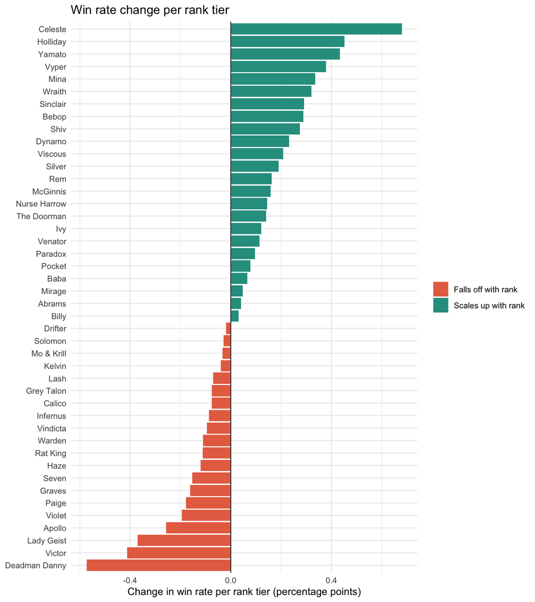

```r
slopes <- hero_rank %>%
  group_by(hero_id, hero_name) %>%
  filter(n() >= 5) %>%
  summarise(slope = unname(coef(lm(win_rate ~ rank_tier, weights = matches))[2]),
            total_matches = sum(matches),
            .groups = "drop") %>%
  mutate(slope_pp = slope * 100,
         trend = if_else(slope_pp >= 0, "Scales up with rank", "Falls off with rank"))

ggplot(slopes, aes(x = slope_pp, y = reorder(hero_name, slope_pp), fill = trend)) +
  geom_col() +
  geom_vline(xintercept = 0, color = "grey30") +
  scale_fill_manual(values = c("Scales up with rank" = "#2a9d8f",
                               "Falls off with rank" = "#e76f51")) +
  labs(title = "Win rate change per rank tier",
       x = "Change in win rate per rank tier (percentage points)",
       y = NULL, fill = NULL) +
  theme_minimal()
```

#### A Closer Look

To take a look at the trend closer, I plotted the win rates of the 4 top characters and 4 bottom characters.

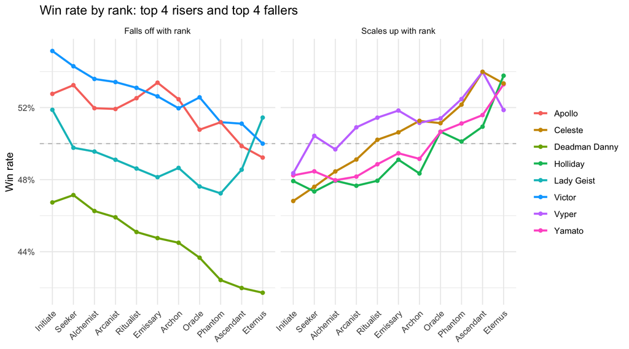

```r
extremes <- bind_rows(slice_max(slopes, slope, n = 4),
                      slice_min(slopes, slope, n = 4)) %>%
  pull(hero_id)

hero_rank %>%
  filter(hero_id %in% extremes) %>%
  left_join(select(slopes, hero_id, trend), by = "hero_id") %>%
  ggplot(aes(rank_name, win_rate, group = hero_name, color = hero_name)) +
  geom_hline(yintercept = 0.5, linetype = "dashed", color = "grey") +
  geom_line(linewidth = 1) + geom_point() +
  facet_wrap(~ trend) +
  scale_y_continuous(labels = scales::percent) +
  labs(title = "Win rate by rank: top 4 risers and top 4 fallers",
       x = NULL, y = "Win rate", color = NULL) +
  theme_minimal() +
  theme(axis.text.x = element_text(angle = 45, hjust = 1))
```

### Learning How to Play Better

I also wanted to look at what factors into winning a game by looking at the correlation between win rate and what a player does during a game. The stats file records totals of what players did in each match, so I can divide by the number of matches to get the average match at each rank and compare Initiate players to Eternus players. Each panel below is one statistic, and the lines run from the lowest rank (left) to the highest (right). Keep in mind that each graph has different y-axes, so the scaling can exaggerate some measuresments.

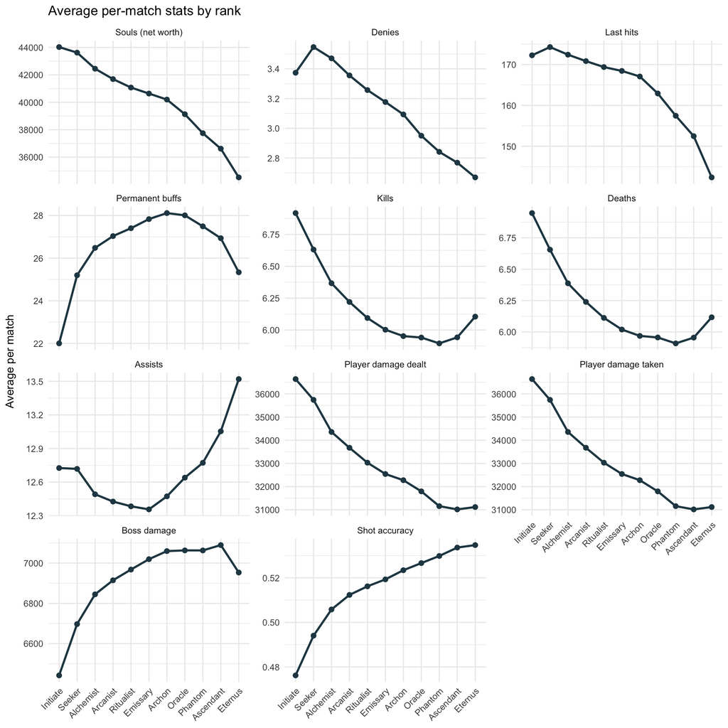

```r
stat_labels <- c(net_worth = "Souls (net worth)", denies = "Denies", last_hits = "Last hits",
                 permanent_buffs = "Permanent buffs", kills = "Kills", deaths = "Deaths",
                 assists = "Assists", damage_dealt = "Player damage dealt",
                 damage_taken = "Player damage taken", boss_damage = "Boss damage",
                 accuracy = "Shot accuracy")

rank_avgs <- hero_rank %>%
  group_by(rank_tier, rank_name) %>%
  summarise(net_worth       = sum(total_net_worth) / sum(matches),
            denies          = sum(total_denies) / sum(matches),
            last_hits       = sum(total_last_hits) / sum(matches),
            permanent_buffs = sum(total_permanent_buffs) / sum(permanent_buff_matches),
            kills           = sum(total_kills) / sum(matches),
            deaths          = sum(total_deaths) / sum(matches),
            assists         = sum(total_assists) / sum(matches),
            damage_dealt    = sum(total_player_damage) / sum(matches),
            damage_taken    = sum(total_player_damage_taken) / sum(matches),
            boss_damage     = sum(total_boss_damage) / sum(matches),
            accuracy        = sum(total_shots_hit) / (sum(total_shots_hit) + sum(total_shots_missed)),
            .groups = "drop") %>%
  pivot_longer(all_of(names(stat_labels)), names_to = "stat", values_to = "value") %>%
  mutate(stat = factor(stat_labels[stat], levels = stat_labels))

ggplot(rank_avgs, aes(rank_name, value, group = 1)) +
  geom_line(linewidth = 1, color = "#264653") +
  geom_point(size = 2, color = "#264653") +
  facet_wrap(~ stat, scales = "free_y", ncol = 3) +
  labs(title = "Average per-match stats by rank",
       x = NULL, y = "Average per match") +
  theme_minimal() +
  theme(axis.text.x = element_text(angle = 45, hjust = 1))
```

Taken together, the panels say that better players play cleaner and more efficiently.

- Aim improves as we get to higher ranks as you can see from the last graph measuring average shot accuracy. This is the single most consistent improvement on the chart, and it never reverses.
- It seems like fights get smaller, but more coordinated as we get higher in rank. Kills, player damage dealt, and damage taken mostly decline with rank (damage dealt falls from about 36,600 to 31,100 per match). At the same time, assists rise at the very top, from a low of about 12.4 at Emissary to 13.5 at Eternus. That suggests more players are contributing to each kill in high-rank fights.
- Objectives, which are the towers/guardians that are in lane, matter a lot more at high ranks. Boss damage rises from about 6,400 at Initiate to about 7,100 at Ascendant, a gain of roughly 10%, so better players spend more of their match pushing objectives.
- An interesting observation that you might notice is how soul net worth from player to player decreases as we get to higher ranks. Net worth falls, and so do denies and last hits fall too. This is surprising because we usually think better players earn more. My best explanation is that high-rank matches end sooner, so players have less time to collect souls, which fits with players dying less and pushing objectives harder. This is only a hypothesis with no data to back it up besides what I know about the game and community.

For a player who wants to climb in rank, the things to improve on are aim, coordination, and pushing objectives, which are skills a player can practice. However, since this data is aggregate data from all heroes, there would be a lot of “it depends on your hero” situations.

#### Stat Correlations to Win Rate

This last section offers a more concise table of how game statistics correlate with win rates at a given rank. For each rank, I compared average per-match stats by hero to their win rates and calculated the correlation (weighted by the number of matches). Correlations run from -1 to 1. Green means heroes with more of that stat tend to win more, orange means they tend to win less, and white means no real relationship.

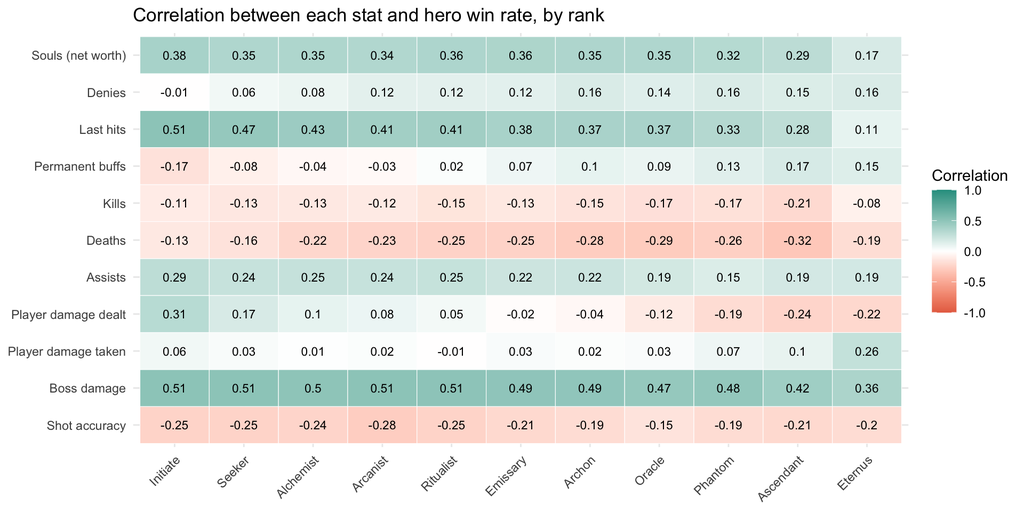

```r
wcor <- function(x, y, w) {
  ok <- !is.na(x) & !is.na(y)
  if (sum(ok) < 5) return(NA_real_)
  cov.wt(cbind(x[ok], y[ok]), wt = w[ok] / sum(w[ok]), cor = TRUE)$cor[1, 2]
}

stat_labels <- c(net_worth = "Souls (net worth)", denies = "Denies", last_hits = "Last hits",
                 permanent_buffs = "Permanent buffs", kills = "Kills", deaths = "Deaths",
                 assists = "Assists", damage_dealt = "Player damage dealt",
                 damage_taken = "Player damage taken", boss_damage = "Boss damage",
                 accuracy = "Shot accuracy")

factor_cor <- hero_rank %>%
  select(hero_name, rank_tier, rank_name, matches, win_rate, all_of(names(stat_labels))) %>%
  pivot_longer(all_of(names(stat_labels)), names_to = "stat", values_to = "value") %>%
  group_by(rank_tier, rank_name, stat) %>%
  summarise(cor = wcor(value, win_rate, matches), .groups = "drop") %>%
  mutate(stat = factor(stat_labels[stat], levels = rev(stat_labels)))

ggplot(factor_cor, aes(rank_name, stat, fill = cor)) +
  geom_tile(color = "white") +
  geom_text(aes(label = round(cor, 2)), size = 3) +
  scale_fill_gradient2(low = "#e76f51", mid = "white", high = "#2a9d8f",
                       midpoint = 0, limits = c(-1, 1), na.value = "grey90") +
  labs(title = "Correlation between each stat and hero win rate, by rank",
       x = NULL, y = NULL, fill = "Correlation") +
  theme_minimal() +
  theme(axis.text.x = element_text(angle = 45, hjust = 1))
```

A lot of the trends here reinforce what I mentioned prior. However, there are some interesting observations.

- Farming matters most at low ranks. Last hits and souls are moderately positive at Initiate and decrease in correlation as ranks go up. At the top, being rich matters less for winning. I am guessing this is due to how higher rank players are more aware of come-back mechanics and how to take advantage of it.
- Raw damage flips sign. Heroes that deal more player damage win more at Initiate but win less at Eternus. Dealing a lot of damage stops being a sign of a winning hero at high ranks.
- Accuracy is negative at every rank. This looks strange next to the earlier finding that aim improves with rank, but it’s comparing heroes, not players. Heroes that land a higher share of their shots don’t win more, which most likely comes down to how each hero is designed. It does not mean that good aim is bad.

Note: This compares heroes, not players inside a match, so I can’t say whether a stat causes winning. Some stats are also partly a result of winning. A team that wins its fights collects more souls, so the souls correlation is partly the win showing up in the stat. Heroes also differ by design, so a stat can say more about the kind of hero than about how well it’s played.

[figure not shown]

## Summary

### Limitations

- The API only gives totals per hero, rank, and day, so I can compare heroes but not individual players, or winners versus losers within a match. Hero-level correlations should not be read as causes.
- I can only guess at explanations like shorter matches at high ranks since we do not have match length data.
- The data covers one month, and the six new heroes had between 6 and 24 days of data, so their pick rates and win rates aren’t directly comparable to the older heroes.
- There is no ban data for the new heroes. They can’t be banned in this patch, so the ban analysis only covers 38 of the 44 heroes.
- Top-rank data is thinner (Eternus has about 114,000 hero-matches, compared with over 1 million at Seeker). I required at least 200 matches per hero and rank, but the highest-rank conclusions are still the noisiest.
- The game is still in development, so these results describe one snapshot of the meta and may be out of date after the next patch.

### Ideas for future work

- Pull the data again after the next patch and compare the two metas directly, using patch notes to separate “players learning” from “Valve rebalancing.”
- Add match duration and item data to test whether souls fall at high ranks because games are shorter.
- Track the new heroes day by day to see how long it takes their win rates to settle.
- Build a regression that predicts win rate from hero, rank, and days since release together, instead of looking at one factor at a time.
- Compare how each hero’s pick and ban rates move by rank to find heroes that are only “feared” at certain skill levels.

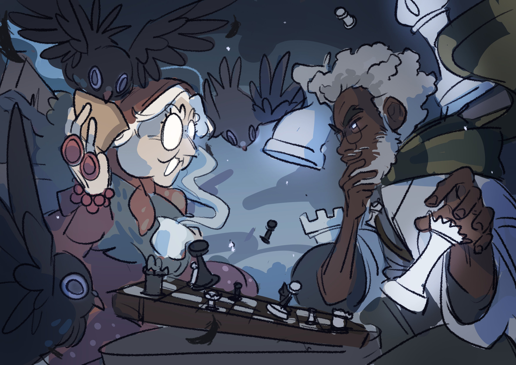

Some cute fanart of Baba and Soloman (two of the new characters) by finnmertens on twitter